# SDARアルゴリズムとその周辺

GCIB企画部CPM戦略企画Gr (CVAデスク) 榎本

## SDARアルゴリズムとは

- ARモデルのパラメータ推定をオンライン忘却的に行うアルゴリズム
- 変化点検知のモデルに応用[[TY06](https://ieeexplore.ieee.org/document/1599387)]
- 古いアルゴリズムだが個人的に興味をもったので紹介

## アルゴリズム紹介...の前に: ARモデル

- AutoRegressiveモデル: 自己の過去の系列に依存して時間発展 <sup>*1</sup> $$ x_t = \mu + a_1 x_{t-1} + \cdots + a_p x_{t-p} + \epsilon_t \\ \epsilon_t \sim N(0, \Sigma) $$
- $\mu, a_1, \cdots, a_p, \Sigma$をデータ$x_1, \cdots, x_n$から推定

$$\sum_{i=1}^{p} a_i C_{j-i} = C_j \qquad (j=1, \cdots, p)$$

*1: ベクトルや行列は全て細字で記述. 慣れなければ変数は全て実数値と思って良い

- $\mu$の推定: 標本平均$\hat{\mu} = \frac{1}{n} \sum_{t=1}^{n} x_t$
- $a_1, \cdots, a_p$の推定: Yule-Walker方程式を解く. $\hat{C}_j$を標本自己共分散として $$\sum_{i=1}^{p} \hat{a}_i \hat{C}_{j-i} = \hat{C}_j \qquad (j=1, \cdots, p)$$
- $\Sigma$の推定: 残差の標本自己分散 $$\hat{\Sigma} = \frac{1}{n-p} \sum_{t=k+1}^{n} \Big( x_t- \sum_{i=1}^{k} \hat{a}_i x_{t-i} \Big) \Big( x_t- \sum_{i=1}^{k} \hat{a}_i x_{t-i} \Big)^T $$

## SDARアルゴリズムとは

- 前スライドの方法はバッチ的
- 仮に各時刻$t$毎にパラメータ推定を行うとすると、計算コストは$O(n^2)$ \ ...金融時系列としても案外馬鹿にならない
- sequentialにパラメータを更新するアルゴリズムとしてSDAR(Sequentially Discounted AutoRegressive)アルゴリズムがある

## SDARアルゴリズム詳細

**Given**: $0 < r < 1$: 忘却パラメータ

**初期化**: \ Set $\hat{\mu}_0, \tilde{C}_{j,0}, \hat{a}_{j,0} (j=1, \cdots, p), \hat{\Sigma}_0$

**更新**: \ For each time $t = 1, 2, \cdots,$ read $x_t$, proceed: $$ \begin{align*} \hat{\mu}_t &= (1-r) \hat{\mu}_{t-1} + r x_t \\ \tilde{C}_{j,t} &= (1-r) \tilde{C}_{j,t-1} + r (x_t - \hat{\mu}_t)(x_{t-j} - \hat{\mu}_t)^T \end{align*} $$

solve Yule-Walker equation: $$ \sum_{i=1}^{p} \hat{a}_{j,t} \tilde{C}_{j-i,t} = \tilde{C}_{j,t} \qquad (j=1, \cdots, p) $$ update parameters: $$ \begin{align*} \hat{x}_t &= \sum_{i=1}^{p} \hat{a}_{j,t}(x_{t-i} - \hat{\mu}_t ) + \hat{\mu}_t \\ \hat{\Sigma}_t &= (1-r) \hat{\Sigma}_{t-1} + r (x_t - \hat{x}_t)(x_t - \hat{x}_t)^T \end{align*} $$

## オンライン忘却型の統計的性質

- 一番簡単な例... iidの時 $x_t \sim Dist(\mu, \Sigma)$ <sup>*1</sup>
  - $\hat{\mu}_t = (1-r) \hat{\mu}_{t-1} + r x_t$
  - $\hat{\Sigma}_t = (1-r) \hat{\Sigma}_{t-1} + r (x_t - \hat\mu_t)(x_t - \hat\mu_t)^T$
- この時,
  - $\lim_{t \to \infty} E(\hat{\mu}_t) = \mu$
  - $\lim_{t \to \infty} Var(\hat{\mu}_t) = \frac{r}{2-r} \Sigma$
  - $\lim_{t \to \infty} E(\hat{\Sigma}_t) = \frac{2(1-r)^2}{2-r} \Sigma$

*1: 平均$\mu$, 分散$\Sigma$の何かしらの分布に従う、という意味

- $\hat{\mu}_t$はasymptotically unbiasedではあるが、$t \to \infty$で収束しない
- $\hat{\Sigma}_t$はasymptotically unbiasedですらない
- 統計的に良い性質持ってないのと意味ないのでは？ \ ...モデルを直接予測に使う以外にも使い途は十分ある！
  - モデルにおけるパラメータ自体がある種の特徴量でもある
  - モデルの当てはめ誤差が大きくなった時点を変化点、と考える \ ...statistical testing-based method[[GS99](https://dl.acm.org/doi/10.1145/312129.312190)]
- SDARであれば、非定常なモデルが扱えるというメリットもある $$ x_t = \mu + \hat{a}_{1, t-1} x_{t-1} + \cdots + \hat{a}_{p, t-1} x_{t-p} + \epsilon_t \\ \epsilon_t \sim N(0, \hat{\Sigma}_{t-1}) $$

## 数値実験1: iidの時

- 実計算時間の比較

```python
time_compare_iid
```

|  | batch | online |
| --- | --- | --- |
| 1000 | 0.006862 | 0.000916 |
| 10000 | 0.073914 | 0.010591 |
| 100000 | 2.380114 | 0.068307 |
| 1000000 | 250.192960 | 0.517799 |

- パラメータ$\hat{\mu}$の収束

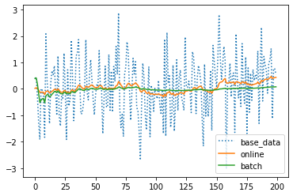

```python
num = 200
base_data[:num].plot(style=":", legend=True)
mu_result_iid_online[:num].plot(legend=True)
mu_result_iid_batch[:num].plot(legend=True)
```

## 数値実験2: ARの時

- 実計算時間の比較

```python
time_compare_sdar
```

|  | AR | SDAR |
| --- | --- | --- |
| 100 | 2.366664 | 0.007896 |
| 500 | 31.023849 | 0.039679 |
| 1000 | 104.606879 | 0.048277 |

- パラメータ$\hat{\Sigma}$ (1次元の分散行列=実数値)

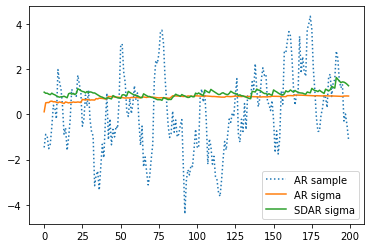

```python
num = 200
ar_samples[:num].plot(style=":", legend=True)
sigma_ar[:num].plot(legend=True)
sigma_sdar[:num].plot(legend=True)
```

## 変化点検知への応用: ChangeFinder

- 詳細: [[argmax](https://argmax.jp/index.php?changefinder)]
- `pip install changefinder`
- サンプルコード

```python
import changefinder
cf = changefinder.ChangeFinder(r=0.01, order=1, smooth=7)

ret = []
for i in data:
    score = cf.update(i)
    ret.append(score)
```

## ChangeFinderアルゴリズム概略

- 学習1段階目⇨スムージング⇨学習2段階目という流れ
- スムージングすることでノイズ由来の外れ値を除去する
- 各学習でSDARを使うことで計算効率化+非定常を前提としたモデリング
1. 学習第1段階
   - SDARで現系列確率密度を学習
   - 各時点での(前時点分布からの)変化点スコアを算出
2. 変化点スコアを平準化=移動平均
3. 学習第1段階
   - SDARで変化点スコア時系列の確率密度を学習
   - 各時点での変化点スコアを算出

## 数値実験例: 人工的なデータ

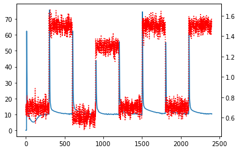

```python
fig = plt.figure()
ax = fig.add_subplot(111); ax2 = ax.twinx()
ax.plot(ret)
ax2.plot(data,'r', linestyle=":")
plt.show()
```

## 実データでは??

- [[山西](https://www.amazon.co.jp/データマイニングによる異常検知-山西-健司/dp/4320018826)]にTOPIX日次データ(期間1985-1995)から原水準+前日差分の2次元データでChangeFinderがワークする例あり
- `changefinder`ライブラリでは1次元のみ対応のため実験未済...

## 発展: 他のモデルへの拡張

- ChangeFinderを拡張することは簡単だが, オンライン型パラメータ推定が必要
- ノンパラへの拡張も提案されている[[II05](https://epubs.siam.org/doi/10.1137/1.9781611972757.63)]
- 最近の応用例: SDAR + Sequential Monte Carlo[[KK15](https://www.jstage.jst.go.jp/article/reajshinrai/37/3/37_KJ00009962106/_article/-char/ja)]やSDAR + SVM[[FD20](https://ieeexplore.ieee.org/document/9310117)]
- ChangeFinder自体は, 機器・設備故障検知やセキュリティ監視などへの応用が多い

## まとめ

- SDARアルゴリズムはオンライン忘却型のパラメータ推定アルゴリズム
- 計算コストは圧倒的に少ないが統計的な性質は弱い
- 一方, モデルパラメータを特徴量と捉えることで, SDARを変化点検知に応用できる
- 変化点検知にはパラメータ変化を素早く検知することが必要

## References (papers)

[[GS99](https://dl.acm.org/doi/10.1145/312129.312190)] V.Guralnik and J.Srivastava: Event detection from time series data. In Proceedings of the fifth ACM SIGKDD international conference on Knowledge discovery and data mining (KDD99), ACM press, pp.32-42, 1999.

[[TY06](https://ieeexplore.ieee.org/document/1599387)] J.Takeuchi and K.Yamanishi: A unifying framework for detecting outliers and change point from time series. IEEE Transaction on Knowledge and Data Engineering, 18(4), pp.482-492, 2006.

[[II05](https://epubs.siam.org/doi/10.1137/1.9781611972757.63)] T.Idé and K.Inoue: Knowledge Discovery from Heterogeneous Dynamic Systems using Change-Point Correlations. Proceedings of the 2005 SIAM International Conference on Data Mining (SDM), pp.571-575, 2005.

[[KK15](https://www.jstage.jst.go.jp/article/reajshinrai/37/3/37_KJ00009962106/_article/-char/ja)] 数実浩佑, 貝戸清之: 統計的変化点検出に基づく社会基盤施設の早期異常検知. 日本信頼性学会誌信頼性37(3), pp.116-125, 2015.

[[FD20](https://ieeexplore.ieee.org/document/9310117)] Y.Furukawa and M.Deng: Fault detection of tank-system using ChangeFinder and SVM. International Conference on Advanced Mechatronic Systems (ICAMechS), pp.260-265, 2020.

## References (textbooks)

[[山西](https://www.amazon.co.jp/データマイニングによる異常検知-山西-健司/dp/4320018826)] 山西健司: データマイニングによる異常検知, 共立出版, 2009.

[[島田](https://www.amazon.co.jp/時系列解析-自己回帰型モデル・状態空間モデル・異常検知-Advanced-島田-直希/dp/4320125010)] 島田直希: 時系列解析: 自己回帰型モデル・状態空間モデル・異常検知 (Advanced Python), 共立出版, 2019.